# Analysis of data from Unfun.me

This script produces all the plots and tables appearing in this paper:

Robert West and Eric Horvitz: **Reverse-Engineering Satire, or “Paper on Computational Humor Accepted Despite Making Serious Advances”.** *Proceedings of the 33rd AAAI Conference on Artificial Intelligence,* 2019.

### Load libraries

```r
library(xtable)
library(plotrix)
library(Matrix)
library(boot)
library(lattice)
```

### Define constants and functions

```r
BASEDIR <- sprintf('../..')
DATADIR <- sprintf('%s/data/', BASEDIR)
PLOTDIR <- sprintf('%s/data/plots/', BASEDIR)

# Source: http://www.cookbook-r.com/Graphs/Colors_(ggplot2)/
COL_LIGHTBLUE <- "#56B4E9"
COL_YELLOW <- "#F0E442"
COL_DARKBLUE <- "#0072B2"
COL_RED <- "#D55E00"
COL_MAGENTA <- "#CC79A7"
COL_GRAY <- "#999999"
COL_ORANGE <- "#E69F00"
COL_GREEN <- "#009E73"

COL_SERIOUS <- COL_GRAY
COL_THEONION <- COL_ORANGE
COL_UNFUN <- COL_GREEN

# Set this to FALSE if you don't want to save plots to PDFs.
SAVE_PLOTS <- FALSE

splitAt <- function(str, sep) strsplit(str, sep)[[1]]

normalizeAndSplitString <- function(str) {
  str <- tolower(str)
  str <- gsub('\\W', ' ', str, perl=TRUE)
  str <- gsub(' +', ' ', str, perl=TRUE)
  str <- gsub('^ | $', '', str, perl=TRUE)
  splitAt(str, ' ')
}

editDist <- function(a, b) {
  # Split at whitespace and punctuation.
  a <- normalizeAndSplitString(a)
  b <- normalizeAndSplitString(b)

  if (length(a) == 0) return(length(b))
  if (length(b) == 0) return(length(a))

  # Distance.
  d <- array(NA, dim=c(length(b)+1, length(a)+1))
  # Operations: -1=del, 0=sub, 1=ins, NA=skip.
  o <- array(NA, dim=c(length(b)+1, length(a)+1))

  # Increment along the first column of each row.
  for (i in 1:(length(b)+1)) {
    d[i,1] <- i-1
    o[i,1] <- -1
  }

  # Increment each column in the first row.
  for (j in 1:(length(a)+1)) {
    d[1,j] <- j-1
    o[1,j] <- 1
  }

  o[1,1] <- NA

  # Fill in the rest of the matrix.
  for (i in 2:(length(b)+1)) {
    for (j in 2:(length(a)+1)) {
      if (b[i-1] == a[j-1]) {
        d[i,j] <- d[i-1,j-1]
      } else {
        d[i,j] <- min(c(d[i-1,j-1] + 1, # substitution
                        d[i,j-1] + 1,   # insertion
                        d[i-1,j] + 1))  # deletion
        if (d[i,j] == d[i-1,j-1] + 1) o[i,j] <- 0
        else if (d[i,j] == d[i,j-1] + 1) o[i,j] <- 1
        else if (d[i,j] == d[i-1,j] + 1) o[i,j] <- -1
      }
    }
  }

  i <- length(b)+1
  j <- length(a)+1
  alg <- NULL
  while (i > 1 || j > 1) {
    alg <- c(o[i,j], alg)
    if (is.na(o[i,j]) || o[i,j] == 0) {
      i <- i-1
      j <- j-1
    } else if (o[i,j] == 1) {
      j <- j-1
    } else if (o[i,j] == -1) {
      i <- i-1
    }
  }

  list(d=d[length(b)+1, length(a)+1], alg=alg)
}

chunkEditDist <- function(a, b, chunkLookup) {
  b_chunked <- chunkLookup[b]
  a_split <- normalizeAndSplitString(a)
  b_split <- normalizeAndSplitString(b)
  result <- list(d=NA, alg=NA, a_lumped=NA, b_lumped=NA, b_chunkLabels=NA,
                 d_plain=NA, alg_plain=NA, insertion_between_chunks=NA)

  # First compute the edit distance on the unchunked versions of a and b.
  ed <- editDist(a, b)
  # This gives an error for one all-Unicode unfunned headline (which we hence include when loading
  # the data).
  b_ops <- ed$alg
  result$d_plain <- ed$d
  result$alg_plain <- ed$alg

  # Fail if there are out-of-chunk tokens, as the "`" in
  # [NP local news report] [VP begins] [PP with] ` [VP get] [NP this] [NP '].
  if (grepl('\\] [^\\[]', b_chunked)) {
    return(result)
  }
  b_chunked <- splitAt(gsub('^\\[|\\]$', '', b_chunked), '\\] \\[')
  b_chunkLabels <- unlist(lapply(b_chunked, function(x) gsub('^([A-Z]*) .*', '\\1', x)))
  b_chunkTexts <- unlist(lapply(b_chunked, function(x) paste(normalizeAndSplitString(gsub('^[A-Z]* (.*)',
                                                                                          '\\1', x)),
                                                             collapse=' ')))
  # Fail if there are empty chunks after normalization or if chunking has messed with the string
  # too much; this happens, e.g., when it splits genitive s from the noun phrase, or transforms
  # "don't" into "do n't'".
  if (any(b_chunkTexts == '') || paste(b_split, collapse=' ') != paste(b_chunkTexts, collapse= ' ')) {
    return(result)
  }
  # Construct a string that indicates for each token in the original string (b) which chunk it
  # belongs to (e.g., "The old man told me" becomes [1,1,1,2,3]).
  i <- 0
  b_chunkMemberships <- unlist(lapply(b_chunkTexts,
                                      function(x) { i <<- i + 1; rep(i, length(splitAt(x, ' '))) }))
  # Construct the same kind of string for the modified string (a).
  a_chunkMemberships <- NULL
  i <- j <- 1
  insertion_between_chunks <- FALSE
  while (j <= length(b_ops)) {
    # We assume that substitutions don't change chunk structure.
    if (b_ops[j] %in% c(NA, 0)) {
      a_chunkMemberships <- c(a_chunkMemberships, b_chunkMemberships[i])
      i <- i + 1
      j <- j + 1
    }
    else if (b_ops[j] == -1) {
      i <- i + 1
      j <- j + 1
    }
    # We assume that insertions extend the chunk that the previous token belonged to.
    else if (b_ops[j] == 1) {
      n <- length(b_chunkMemberships)
      prev_chunk <- b_chunkMemberships[if (i>1) i-1 else 1]
      next_chunk <- b_chunkMemberships[if (i<=n) i else n]
      a_chunkMemberships <- c(a_chunkMemberships, prev_chunk)
      if (prev_chunk != next_chunk) {
        insertion_between_chunks <- TRUE
      }
      j <- j + 1
    }
  }
  # A function for lumping all tokens of the same chunk into a single string, e.g.,
  # "The_old_man told me".
  lump <- function(tokens, memberships) {
    pasted <- ''
    for (i in 1:length(memberships)) {
      if (i == 1) pasted <- tokens[1]
      else if (memberships[i] == memberships[i-1]) pasted <- paste(pasted, tokens[i], sep='_')
      else pasted <- paste(pasted, tokens[i], sep=' ')
    }
    pasted
  }

  a_lumped <- lump(a_split, a_chunkMemberships)
  b_lumped <- lump(b_split, b_chunkMemberships)
  ed_lumped <- editDist(a_lumped, b_lumped)
  result$d <- ed_lumped$d
  result$alg <- ed_lumped$alg
  result$a_lumped <- a_lumped
  result$b_lumped <- b_lumped
  result$b_chunkLabels <- b_chunkLabels
  result$insertion_between_chunks <- insertion_between_chunks
  return(result)
}

plot_edit_dist_hist <- function(x, col, xlab, xlim=c(0,max(x)), filename=NULL,
                                print_left_ylab=TRUE, print_right_ylab=TRUE) {
  if (SAVE_PLOTS) pdf(sprintf('%s/%s.pdf', PLOTDIR, filename), width=1.7, height=1.4, pointsize=6,
                      family='Helvetica', useDingbats=FALSE)
  par(mar=c(3.2, 3.4, 0.8, 3.4))
  h <- hist(x, breaks=0:max(x), xlab='', ylab='', main=NULL, xlim=xlim, axes=FALSE, col=col, border=NA)
  cum <- cumsum(h$counts)/sum(h$counts)
  ticks <- seq(1, xlim[2] + 0.5, 2)
  axis(1, at=ticks-0.5, labels=ticks, las=2)
  mtext(xlab, side=1, line=2)
  if (!SAVE_PLOTS || print_left_ylab) {
    axis(2, col=col, col.axis=col)
    mtext('Number of pairs', side=2, line=2, col=col)
  }
  par(new=TRUE)
  plot(h$breaks[-1]-0.5, cum, type='p', xlab='', ylab='', xlim=xlim, ylim=c(0,1), axes=FALSE)
  if (!SAVE_PLOTS || print_right_ylab) {
    axis(4)
    mtext('Cumulative rel. frequency', side=4, line=2)
  }
  if (SAVE_PLOTS) dev.off()
  return(h)
}

bootstrap_ci <- function(x) {
  bo <- boot(x, statistic=function(d, i) return(mean(d[i], na.rm=TRUE)), R=5000)
  ci <- boot.ci(bo, conf=0.95, type="basic")$basic[4:5]
  if (is.null(ci)) {
    upper <- lower <- NA
  } else {
    lower <- ci[1]
    upper <- ci[2]
  }
  list(upper=upper, mean=mean(x, na.rm=TRUE), lower=lower)
}
```

### Load data

```r
# chunkLookup: mapping from headlines to chunked versions.
chunkData <- read.table(sprintf('%s/headlines_for_game_ANALYZED_AUGMENTED_LOWERCASE_HEADLINESTYLE.tsv', DATADIR),
                       sep="\t", quote="", comment.char="", stringsAsFactors=FALSE, encoding="UTF-8")
colnames(chunkData) <- c('title', 'chunks', 'chunk_labels')
chunkLookup <- chunkData[,2]
names(chunkLookup) <- chunkData[,1]

# or: data from "Real or not?" task: rated original headlines from The Onion as well as serious outlets.
or <- read.table(sprintf('%s/%s', DATADIR, "original_headlines_with_ratings.tsv"), header=TRUE,
  sep="\t", quote="\"", comment.char="", stringsAsFactors=FALSE, encoding="UTF-8")
# Ratings: 0 = satirical, 1 = serious (need to flip because on the Unfun website, 0 means real).
or$rating <- 1 - as.numeric(or$rating)
or$truth_type <- or$truth_type == 'real'

# d: data from the "Unfun the headline!" task: pairs of real and unfunned versions, alongside rating.
# The same pair appears as many times as it was rated.
d <- read.table(sprintf('%s/%s', DATADIR, "pairs_with_ratings.tsv"), header=TRUE,
  sep="\t", quote="\"", comment.char="", stringsAsFactors=FALSE, encoding="UTF-8")
# Filter to include only pairs with at least one rating.
d$rating[d$rating == 'NULL'] <- NA
# Ratings: 0 = satirical, 1 = serious (need to flip because in Unfun 0 means real).
d$rating <- 1 - as.numeric(d$rating)
# Manually remove a nasty Unicode line that screws things up somehow.
d <- d[d$id != 4381,]

# Single-substitution pairs, labeled with script opposition.
scr_opp <- read.table(sprintf('%s/pairs_editdist_1_SCRIPT-OPPOSITION.tsv', DATADIR), header=TRUE,
                      sep="\t", quote="", comment.char="", stringsAsFactors=FALSE, encoding="UTF-8")

# Ids of the unfunned headlines that have at least two ratings, with more than half of them above 0.5.
idx <- which(!is.na(d$rating))
xxx <- d[d$id %in% names(which(tapply(d$rating[idx], d$id[idx], length) >= 2)),]
n <- length(unique(xxx$id))
GOOD_IDS <- names(which(tapply(xxx$rating, xxx$id, function(x) mean(round(x), na.rm=TRUE) > 0.5)))
num_successfully_unfunned <- length(GOOD_IDS)
frac_successfully_unfunned <- num_successfully_unfunned / n
BAD_IDS <- names(which(tapply(xxx$rating, xxx$id, function(x) mean(round(x), na.rm=TRUE) < 0.5)))
num_failed_unfunned <- length(BAD_IDS)
frac_failed_unfunned <- num_failed_unfunned / n
num_unfunned_at_least_2_ratings <- n

# r: one row per unfunned headline, all ratings for the same headline grouped together, and including
# chunk and edit-distance information.
r <- by(d, d$id, function(x) c(x$uid[1], x$original_id[1], x$id[1], x$original_title[1], x$title[1]))
r <- data.frame(do.call(rbind, r))
colnames(r) <- c('uid', 'original_id', 'id', 'original_title', 'title')
r$ratings <- lapply(r$id, function(id) d$rating[d$id==id])
r$mean_rating <- sapply(r$ratings, function(x) mean(x, na.rm=TRUE))
# Add edit information.
edits <- apply(r, 1, function(row) chunkEditDist(row$title, row$original_title, chunkLookup))
r$title_lumped <- sapply(edits, function(e) e$a_lumped)
r$original_title_lumped <- sapply(edits, function(e) e$b_lumped)
r$original_chunkLabels <- sapply(edits, function(e) e$b_chunkLabels)
r$dist_plain <- sapply(edits, function(e) e$d_plain)
r$alg_plain <- sapply(edits, function(e) e$alg_plain)
r$dist <- sapply(edits, function(e) e$d)
r$alg <- sapply(edits, function(e) e$alg)
r$insertion_between_chunks <- sapply(edits, function(e) e$insertion_between_chunks)
r$len <- sapply(r$title, function(t) length(normalizeAndSplitString(t)))
r$origlen <- sapply(r$original_title, function(t) length(normalizeAndSplitString(t)))
r$reldist <- r$dist / apply(r[,c('len', 'origlen')], 1, max)
r$has_token_based_insertion <- sapply(r$alg_plain, function(x) any(x==1, na.rm=TRUE))

# r_clean: same as r, but without headlines where chunking didn't give a clean result and where there's an
# insertion that cannot be unambiguously attributed to a chunk.
r_clean <- r[!is.na(r$dist) & !r$insertion_between_chunks,]
```

### Basic dataset stats

```r
# Number of unique headlines from The Onion for which we have at least one unfunned version.
num_orig_headlines <- length(unique(d$original_id)) # 1,191

# Number of unfunned versions with at least 0, 1, 2 ratings.
# Sanity check: ..._0 is the same as length(unique(d$id)).
num_unfunned_versions_0 <- sum(tapply(d$rating, d$id, function(x) sum(!is.na(x)) >= 0)) # 2,801
num_unfunned_versions_0
```

```
## [1] 2801
```

```r
num_unfunned_versions_1 <- sum(tapply(d$rating, d$id, function(x) sum(!is.na(x)) >= 1)) # 2,793
num_unfunned_versions_1
```

```
## [1] 2793
```

```r
num_unfunned_versions_2 <- sum(tapply(d$rating, d$id, function(x) sum(!is.na(x)) >= 2)) # 1,806
num_unfunned_versions_2
```

```
## [1] 1806
```

```r
# Number of unique user ids.
num_uniq_uids_unfunned <- length(unique(d$uid)) # 582
num_uniq_uids_unfunned
```

```
## [1] 582
```

```r
num_uniq_uids_rating <- length(unique(or$uid)) # 546
num_uniq_uids_rating
```

```
## [1] 546
```

```r
jaccard_unfunning_rating <- length(intersect(d$uid, or$uid)) / length(union(d$uid, or$uid)) # 0.7708
jaccard_unfunning_rating
```

```
## [1] 0.7708006
```

```r
# Mean/median number of ratings per user.
mean_num_ratings_per_uid <- mean(tapply(or$uid, or$uid, length)) # 10.17399
mean_num_ratings_per_uid
```

```
## [1] 10.17399
```

```r
median_num_ratings_per_uid <- median(tapply(or$uid, or$uid, length)) # 4
median_num_ratings_per_uid
```

```
## [1] 4
```

```r
# Mean/median number of unfunned headlines per user.
mean_num_unfunned_per_uid <- mean(tapply(d$id, d$uid, function(x) length(unique(x)))) # 4.812715
mean_num_unfunned_per_uid
```

```
## [1] 4.812715
```

```r
median_num_unfunned_per_uid <- median(tapply(d$id, d$uid, function(x) length(unique(x)))) # 2
median_num_unfunned_per_uid
```

```
## [1] 2
```

In summary, we have collected 2801 unfunned versions for 1191 distinct headlines from The Onion. 2793 (1806) unfunned versions have received at least 1 (2) ratings. The unfunned headlines came from 582 unique uids (mean/median number of unfunned versions per user: 4.8127148/2). The ratings came from 546 unique uids (mean/median number of ratings per user: 10.1739927/4).

### Rating histograms

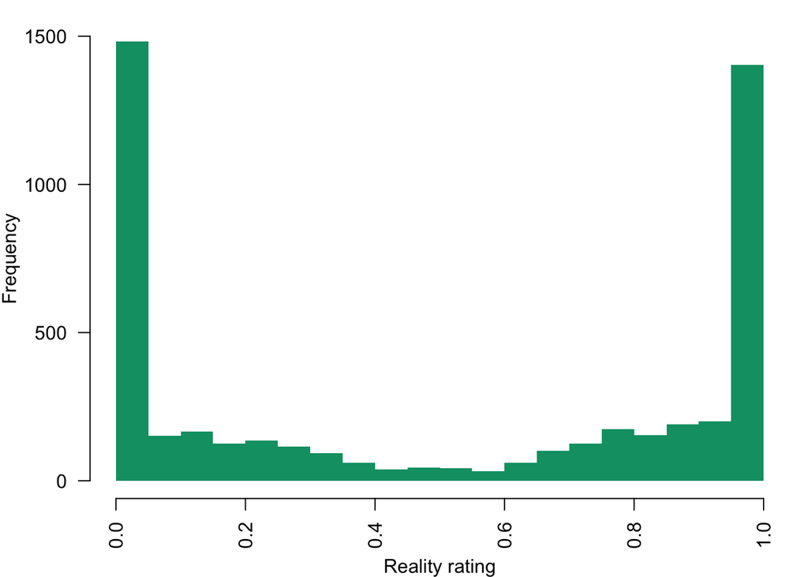

```r
plot_rating_hist <- function(x, col, filename=NULL, print_ylab=TRUE) {
  if (SAVE_PLOTS) pdf(sprintf('%s/%s.pdf', PLOTDIR, filename), width=1.4, height=1, pointsize=6,
                      family='Helvetica', useDingbats=FALSE)
  par(mar=c(3.4, 3.9, 0.8, 0.8))
  hist(x, xlab='', ylab='', breaks=20, col=col, border=NA, main='', ylim=c(0,1500), axes=FALSE)
  axis(1, las=2)
  if (!SAVE_PLOTS || print_ylab) {
    axis(2, las=2)
    mtext('Frequency', side=2, line=3)
  }
  mtext('Reality rating', side=1, line=2.4)
  if (SAVE_PLOTS) dev.off()
}

# Rating histogram for unfunned versions of satirical headlines.
h1 <- plot_rating_hist(d$rating, COL_UNFUN, 'rating_hist_UNFUNNED', TRUE)
```

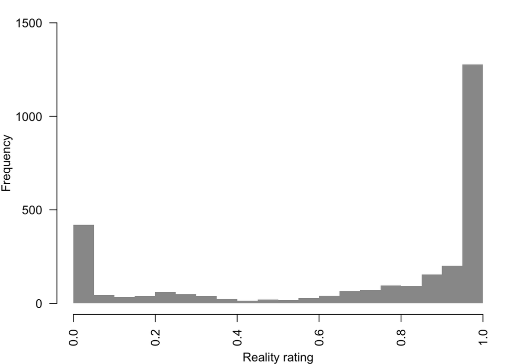

```r
# Rating histogram for serious headlines.
h2 <- plot_rating_hist(or$rating[or$truth_type==TRUE], COL_SERIOUS, 'rating_hist_SERIOUS', FALSE)
```

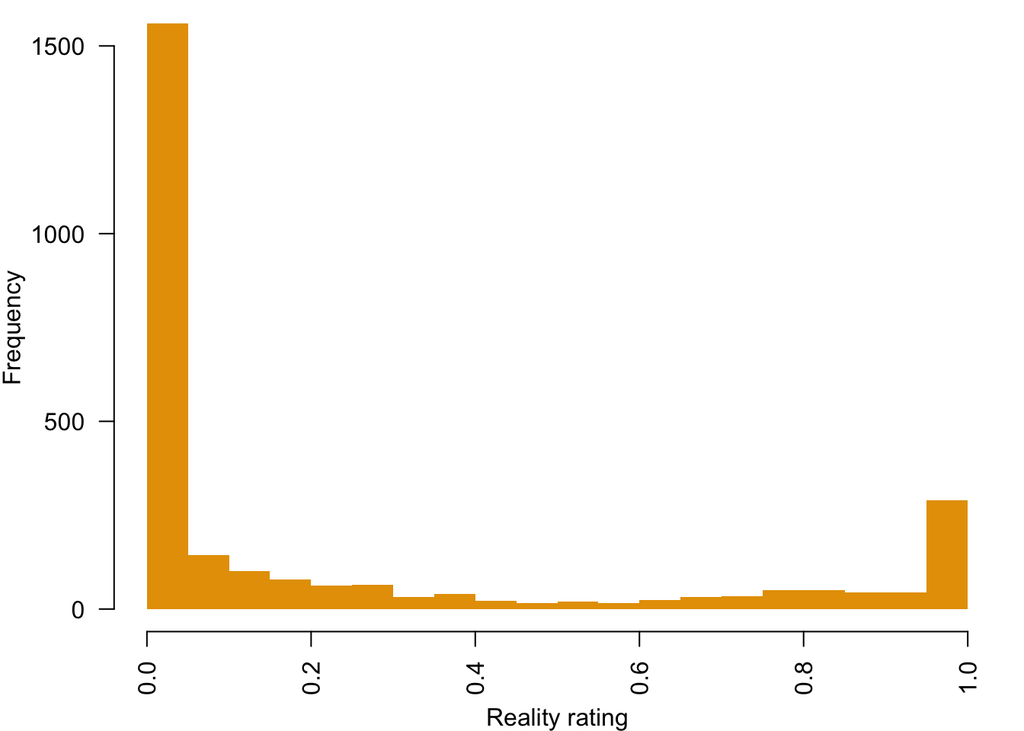

```r
# Rating histogram for satirical headlines from The Onion.
h3 <- plot_rating_hist(or$rating[or$truth_type==FALSE], COL_THEONION, 'rating_hist_THEONION', FALSE)
```

The above shows that people tend to choose extreme, mostly binary ratings.

### Histogram of token-based edit distance

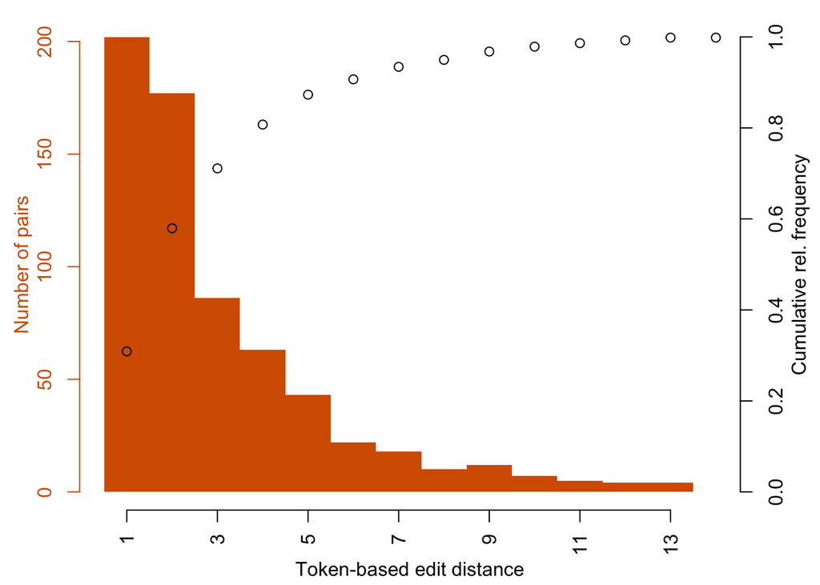

```r
xlim <- c(0, 13.5)

# Only successfully unfunned headlines.
h <- plot_edit_dist_hist(r$dist_plain[r$id %in% GOOD_IDS], COL_RED, 'Token-based edit distance', xlim,
                         'edit_dist_hist_TOKENS_SUCCESSFUL')
```

```r
# List the values of the black dots in the above plot.
cum <- cumsum(h$counts)/sum(h$counts)
cum
```

```
##  [1] 0.3088685 0.5795107 0.7110092 0.8073394 0.8730887 0.9067278 0.9342508
##  [8] 0.9495413 0.9678899 0.9785933 0.9862385 0.9923547 0.9984709 0.9984709
## [15] 0.9984709 0.9984709 0.9984709 1.0000000
```

That is, considering only headlines with token-based edit distance up to 1, 2, 3 gives us 31%, 58%, 71% of the headlines, respectively (when restricting to successful headlines only).

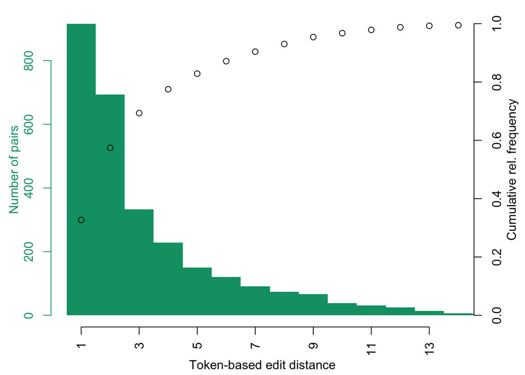

```r
# All unfunned headlines.
h <- plot_edit_dist_hist(r$dist_plain, COL_UNFUN, 'Token-based edit distance', xlim, 'edit_dist_hist_TOKENS_ALL')
```

```r
# List the values of the black dots in the above plot.
cum <- cumsum(h$counts)/sum(h$counts)
cum
```

```
##  [1] 0.3270261 0.5744377 0.6933238 0.7750803 0.8286326 0.8714745 0.9039629
##  [8] 0.9303820 0.9539450 0.9675116 0.9785791 0.9875045 0.9925027 0.9946448
## [15] 0.9960728 0.9964298 0.9975009 0.9992860 0.9996430 0.9996430 0.9996430
## [22] 0.9996430 0.9996430 0.9996430 0.9996430 0.9996430 0.9996430 0.9996430
## [29] 1.0000000
```

That is, considering only headlines with token-based edit distance up to 1, 2, 3 gives us 33%, 57%, 69% of the headlines, respectively (when not restricting to successful headlines only).

### Ratings as a function of edit distance

```r
# Here we consider only headlines with at least 2 ratings.
idx2 <- which(simplify2array(lapply(r$ratings, function(x) sum(!is.na(x)))) >= 2)
mean_and_ci <- as.data.frame(t(simplify2array(by(r$mean_rating[idx2], r$dist_plain[idx2], bootstrap_ci))))
```

```
## [1] "All values of t are equal to  0.4 \n Cannot calculate confidence intervals"
## [1] "All values of t are equal to  0.5 \n Cannot calculate confidence intervals"
## [1] "All values of t are equal to  0.606 \n Cannot calculate confidence intervals"
```

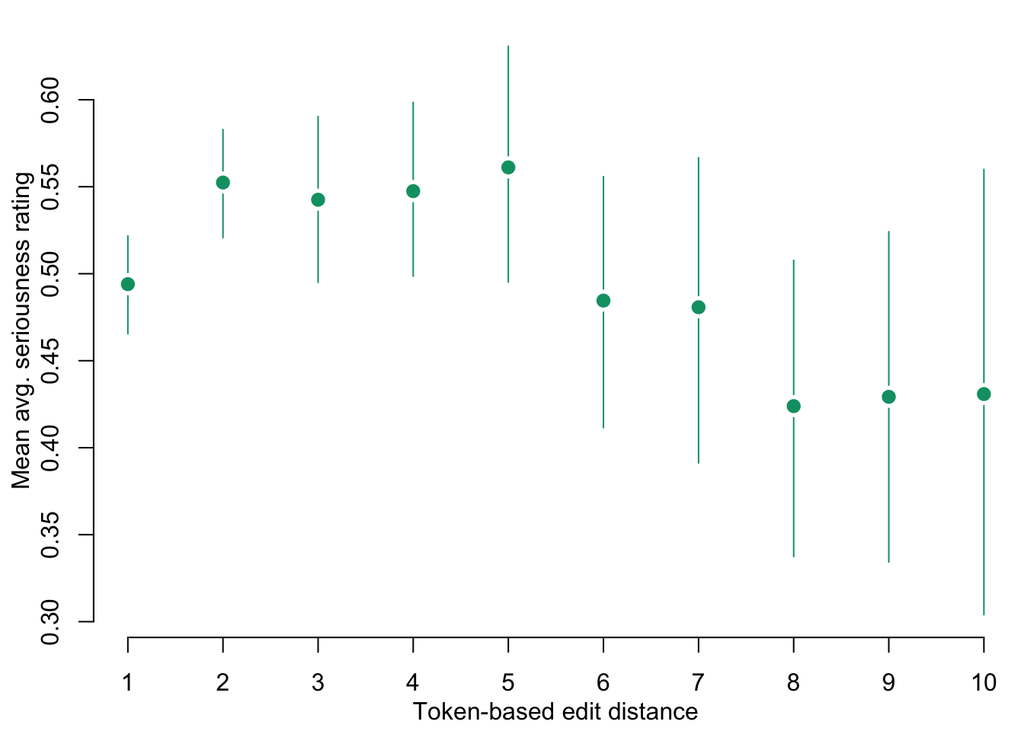

```r
x <- 1:10
y <- as.numeric(mean_and_ci$mean[x])
lo <- as.numeric(mean_and_ci$lower[x])
hi <- as.numeric(mean_and_ci$upper[x])

if (SAVE_PLOTS) pdf(sprintf('%s/edit_dist_vs_rating.pdf', PLOTDIR), width=1.7, height=1.4, pointsize=6,
                    family='Helvetica', useDingbats=FALSE)
par(mar=c(3.2, 3.2, 0.8, 0.2))
plot(x, y, ylim=range(c(lo, hi)), type='p', bty='n', lwd=2, xlab='', ylab='',
     col=COL_UNFUN, xaxt='n', pch=20, cex=1.5)
axis(1, at=x)
dispersion(x, y, hi, lo, intervals=FALSE, col=COL_UNFUN, arrow.cap=0)
mtext('Token-based edit distance', side=1, line=2)
mtext('Mean avg. seriousness rating', side=2, line=2)
```

```r
if (SAVE_PLOTS) dev.off()
```

### Numbers/fractions of serious, satirical, unfunned headlines with majority agreement

```r
real_idx <- which(or$truth_type == TRUE)
sat_idx <- which(or$truth_type == FALSE)

# Serious headlines with at least 2 ratings that are rated as satirical by more than half of all raters.
or_real <- or[or$id %in% names(which(tapply(or$id[real_idx], or$id[real_idx], length) >= 2)),]
deceptive_real_ids <- names(which(tapply(or_real$rating, or_real$id,
                                         function(x) mean(round(x), na.rm=TRUE) < 0.5)))
num_deceptive_real <- length(deceptive_real_ids)
frac_deceptive_real <- num_deceptive_real / length(unique(or_real$id)) # 9.9%
num_deceptive_real
```

```
## [1] 133
```

```r
frac_deceptive_real
```

```
## [1] 0.09801032
```

```r
easy_real_ids <- names(which(tapply(or_real$rating, or_real$id,
                                    function(x) mean(round(x), na.rm=TRUE) > 0.5)))
num_easy_real <- length(easy_real_ids)
frac_easy_real <- num_easy_real / length(unique(or_real$id)) # 57.3%
num_easy_real
```

```
## [1] 777
```

```r
frac_easy_real
```

```
## [1] 0.5725866
```

```r
length(unique(or_real$id)) - num_deceptive_real - num_easy_real
```

```
## [1] 447
```

```r
(length(unique(or_real$id)) - num_deceptive_real - num_easy_real) / length(unique(or_real$id))
```

```
## [1] 0.3294031
```

```r
# Satirical headlines with at least 2 ratings that are rated as serious by more than half of all raters.
or_sat <- or[or$id %in% names(which(tapply(or$id[sat_idx], or$id[sat_idx], length) >= 2)),]
deceptive_sat_ids <- names(which(tapply(or_sat$rating, or_sat$id,
                                        function(x) mean(round(x), na.rm=TRUE) > 0.5)))
num_deceptive_sat <- length(deceptive_sat_ids)
frac_deceptive_sat <- num_deceptive_sat / length(unique(or_sat$id)) # 7.8%
num_deceptive_sat
```

```
## [1] 105
```

```r
frac_deceptive_sat
```

```
## [1] 0.078125
```

```r
easy_sat_ids <- names(which(tapply(or_sat$rating, or_sat$id,
                                   function(x) mean(round(x), na.rm=TRUE) < 0.5)))
num_easy_sat <- length(easy_sat_ids)
frac_easy_sat <- num_easy_sat / length(unique(or_sat$id)) # 64.8%
num_easy_sat
```

```
## [1] 871
```

```r
frac_easy_sat
```

```
## [1] 0.6480655
```

```r
length(unique(or_sat$id)) - num_deceptive_sat - num_easy_sat
```

```
## [1] 368
```

```r
(length(unique(or_sat$id)) - num_deceptive_sat - num_easy_sat) / length(unique(or_sat$id))
```

```
## [1] 0.2738095
```

```r
num_successfully_unfunned # 654
```

```
## [1] 654
```

```r
frac_successfully_unfunned # 36.2%
```

```
## [1] 0.3621262
```

```r
num_failed_unfunned # 582
```

```
## [1] 582
```

```r
frac_failed_unfunned # 32.2%
```

```
## [1] 0.3222591
```

```r
num_unfunned_at_least_2_ratings - num_successfully_unfunned - num_failed_unfunned
```

```
## [1] 570
```

```r
(num_unfunned_at_least_2_ratings - num_successfully_unfunned -
    num_failed_unfunned) / num_unfunned_at_least_2_ratings
```

```
## [1] 0.3156146
```

In summary, there are 133 (10%) real, serious headlines (with at least 2 ratings) that are mistaken as satirical by more than half of all raters. There are 777 (57%) real, serious headlines (with at least 2 ratings) that are correctly labeled by more than half of all raters.

There are 105 (8%) headlines from The Onion (with at least 2 ratings) that are mistaken as serious by more than half of all raters. There are 871 (65%) headlines from The Onion (with at least 2 ratings) that are correctly labeled by more than half of all raters.

There are 582 (32%) unfunned versions (with at least 2 ratings) that are labeled as satirical by more than half of all raters. These are definitely failed attempts at unfunning, so we should discard them. There are 654 (36%) unfunned versions (with at least 2 ratings) that are labeled as serious by more than half of all raters. We will focus on these for most of our analysis.

### Example headlines

```r
# Some consistently misclassified serious headlines.
sample(unique(or$title[or$id %in% deceptive_real_ids]), 20)
```

```
##  [1] "heart and soul: heart and soul"
##  [2] "phil anastasia: washington twp. trio no lightweights on mat"
##  [3] "the final word: this thanksgiving, roll out mom's apple pie"
##  [4] "with economy slow, canada to hold early elections"
##  [5] "mcavoy is amusing indeed in this coming-of-age comedy"
##  [6] "skye house twinkles for christmas"
##  [7] "the mike harding show: 04/11/2009"
##  [8] "japan: a story of love and hate"
##  [9] "the adventure show: 2008/2009: world cup mountain"
## [10] "glastonbury: 2009: the best bits: part 2"
## [11] "serial mistress claims she is helping ailing marriages"
## [12] "theme time radio hour with bob dylan: 30/10/2008"
## [13] "netflix, tivo team up after 4-year courtship"
## [14] "cult - the hitchhiker's guide to the galaxy"
## [15] "electric proms: 2009: robbie williams"
## [16] "persuading us to be good"
## [17] "users baffled as zune mp3 players freeze up"
## [18] "will ferrell has halloween fun with usc trojans"
## [19] "the national lottery: big 7: 2009"
## [20] "time shift: series 7: the rise and fall of the ad man"
```

```r
# Some consistently misclassified satirical headlines.
sample(unique(or$title[or$id %in% deceptive_sat_ids]), 20)
```

```
##  [1] "ESPN The Magazine Releases Special 'Sports Journalism' Issue"
##  [2] "Millions Of Human Beings Experiencing Actual Emotions About J.J. Abrams Directing 'Star Wars'"
##  [3] "Area Woman Already Planning Party For 'Mad Men' Series Finale"
##  [4] "UPDATE: Taylor Swift Back Together With Ex-Boyfriend Christopher Dorner"
##  [5] "Historical Archives: Sing Ho! For the KING of Broil'd MEATS"
##  [6] "Ben Affleck Defends Decision To Set 'Argo' In Boston"
##  [7] "Chad Pennington Getting Into Groove After Season-Ending Shoulder Injury"
##  [8] "Dan Gilbert Pledges Cavaliers Will Win Championship Before LeBron Wins Eighth Title"
##  [9] "Powerful Rest And Fluids Industry Influencing Doctors' Treatment Of Colds"
## [10] "Wife Always Dragging Husband Into Her Marital Problems"
## [11] "New Hampshire Primary Excites Tiny Percentage Of Population Who Even Cares What Happens Anymore"
## [12] "New Law Prohibits Kaleidoscoping While Driving"
## [13] "Historical Archives: Notice To The Publik"
## [14] "Grown-Up Ferris Bueller Charms His Way Out Of Paying Child Support"
## [15] "And-1 Basketball Player's Amazing New Dribbling Move Still Traveling"
## [16] "Mitt Romney Adopts New ‘Ronnie Ferocious’ Persona For Debates"
## [17] "'I Feel Your Pain,' Romney Tells Campaign Rally Attendees Who Make $20 Million A Year"
## [18] "Buzzfeed Sports To Focus On Fun, Lighter Side Of Other People's Sports Coverage"
## [19] "Obese Woman Puts Dog On Diet"
## [20] "Baltimore Ravens Admit They Like The Ugly Wins"
```

```r
# Some successfully unfunned headlines.
xxx <- d[d$id %in% sample(GOOD_IDS, 20),]
yyy <- t(simplify2array(by(xxx, apply(xxx, 1, function(x) paste(x[1], x[2])),
                           function(x) c(x$original_title[1], x$title[1]))))
colnames(yyy) <- c('original', 'unfunned')
rownames(yyy) <- NULL
yyy
```

```
##       original
##  [1,] "Scandalous Photos Reveal Grover Norquist Carried On Secret Affair With Taxes For Years"
##  [2,] "Obama Orders Guantánamo Prisoners Transferred To Next President"
##  [3,] "Local Historian Has Big News For Grover Cleveland Fans"
##  [4,] "Report: Majority Of Government Doesn't Trust Citizens Either"
##  [5,] "Local Bar Comes Out As Gay"
##  [6,] "College Unveils New Media Center Every Month"
##  [7,] "Mother Knows Perfect Picture To Publicize If Daughter Ever Abducted"
##  [8,] "Sports Drinks Face Competition From New Sitting-On-Couch-Watching-TV Drinks"
##  [9,] "Raiders Still Looking For Free Agents With Proven Track Record Of Never Playing On Raiders"
## [10,] "Little League World Series to Begin Testing Players For Mustaches"
## [11,] "Bush Finds Error In Fermilab Calculations"
## [12,] "College-Aged Female Finds Unlikely Kindred Spirit In Audrey Hepburn"
## [13,] "Mitt Romney Adopts New ‘Ronnie Ferocious’ Persona For Debates"
## [14,] "City Opens New Art Jail"
```

[output cut: 27 more lines]

```r
# Some failed unfunned headlines.
xxx <- d[d$id %in% sample(BAD_IDS, 20),]
yyy <- t(simplify2array(by(xxx, apply(xxx, 1, function(x) paste(x[1], x[2])),
                           function(x) c(x$original_title[1], x$title[1]))))
colnames(yyy) <- c('original', 'unfunned')
rownames(yyy) <- NULL
yyy
```

```
##       original
##  [1,] "Sports Profile Begins With Humorous Clubhouse Anecdote Before Delving Into What Player's Life Was Like Couple Years Ago"
##  [2,] "New Denim Jacket Bolsters Consumer Self-Confidence"
##  [3,] "City Should Do Something About It"
##  [4,] "Movie Characters Happen To Pass Through Pamplona On The One Week Bulls Run"
##  [5,] "Report: It Not Worth Staying Past Fifth Inning Of 83% Of Baseball Games"
##  [6,] "Report: 100 Percent Of College Football Players Receiving Benefits Of Being College Football Players"
##  [7,] "Scientists Teach Sign Language To Gorilla-Suit-Wearing Man"
##  [8,] "Sports Movie Protagonist Receives Some Bad News Before Big Game"
##  [9,] "Man Has Never Given Single Definitive Yes To Any Invitation He's Ever Received"
## [10,] "Obama Administration Releases Nation’s Phone Records To Public"
## [11,] "Troy Aikman Fruitlessly Attempts To Conjure Super Bowl Memory For On-Air Anecdote"
## [12,] "Mattress King Selects Wife From Small Wisconsin Village"
## [13,] "Machiavellian White House Groundskeeper Gaining Influence Among West Wing Staff"
## [14,] "Tim Duncan Offers Legal Advice To Wife’s Divorce Lawyer"
```

[output cut: 27 more lines]

### Distribution of edit operations

We consider only successfully unfunned headlines here.

```r
compute_edit_hist <- function(dists) {
  edit_distrib <- lapply(dists, function(x) c(sum(x==1, na.rm=TRUE),
                                              sum(x==-1, na.rm=TRUE), sum(x==0, na.rm=TRUE)) / sum(!is.na(x)))
  edit_distrib <- data.frame(do.call(rbind, edit_distrib))
  colnames(edit_distrib) <- c('Insertion', 'Deletion', 'Substit.')
  colMeans(edit_distrib)
}

h_all <- compute_edit_hist(r$alg_plain[r$id %in% GOOD_IDS])
h_1 <- compute_edit_hist(r$alg_plain[r$id %in% GOOD_IDS & r$dist_plain==1])

# All pairs.
h_all
```

```
##  Insertion   Deletion   Substit.
## 0.05064788 0.33507893 0.61427319
```

```r
# Only pairs with edit distance 1.
h_1
```

```
##  Insertion   Deletion   Substit.
## 0.01980198 0.20792079 0.77227723
```

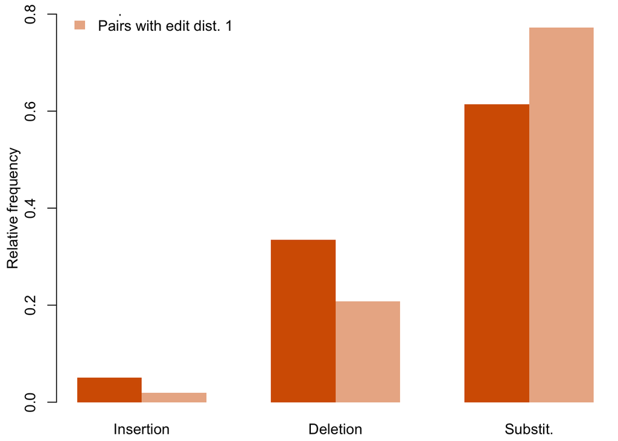

```r
if (SAVE_PLOTS) pdf(sprintf('%s/edit_type_hist_SUCCESSFUL.pdf', PLOTDIR), width=1.7, height=1.4, pointsize=6,
                    family='Helvetica', useDingbats=FALSE)
par(mar=c(2.2, 3.2, 0.8, 0.2))
col <- COL_RED
barplot(rbind(h_all, h_1), beside=TRUE, col=c(col, sprintf('%s80', col)), border=NA, ylim=c(0,0.8))
mtext('Relative frequency', side=2, line=2)
legend(x=0.75, y=0.85, legend=c('All pairs', 'Pairs with edit dist. 1'), bty='n',
       fill=c(col, sprintf('%s80', col)), border=NA)
```

```r
if (SAVE_PLOTS) dev.off()
```

### Most frequent syntactic patterns

We parse all 9159 Onion headlines used in the game using a shallow parser (a.k.a. chunker). These are the most frequent syntactic patterns (chunk sequences):

```r
h <- sort(tapply(chunkData$chunk_labels, chunkData$chunk_labels, length), decreasing=TRUE)
chunk_seq_hist <- data.frame(freq=h, rel_freq=round(h/sum(h), 3))
head(chunk_seq_hist, 10)
```

```
##                      freq rel_freq
## NP VP NP PP NP        443    0.048
## NP VP NP              392    0.043
## NP VP PP NP           300    0.033
## NP VP PP NP PP NP     156    0.017
## NP VP NP PP NP PP NP  143    0.016
## NP PP NP              140    0.015
## NP VP NP VP NP        108    0.012
## NP PP NP PP NP         93    0.010
## NP VP NP VP PP NP      82    0.009
## NP VP NP VP NP PP NP   80    0.009
```

### Histogram of chunk-based edit distance

From here on, we discard headlines where the original or the unfunned versions contains out-of-chunk tokens and where there’s an insertion that cannot be unambiguously attributed to a chunk.

```r
frac_insertion_between_chunks <- sum(!is.na(r$dist) & r$insertion_between_chunks) / sum(!is.na(r$dist))
```

The latter filter removes only 8.0122592% of the headlines without out-of-chunk tokens.

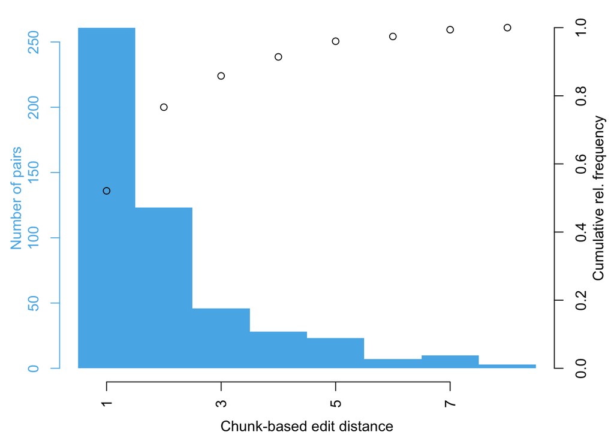

```r
h <- plot_edit_dist_hist(r_clean$dist[r_clean$id %in% GOOD_IDS], COL_LIGHTBLUE, xlab='Chunk-based edit distance',
                         filename='edit_dist_hist_CHUNKS')
```

```r
cum <- cumsum(h$counts)/sum(h$counts)
```

That is, considering only headlines with chunked edit distance up to 1, 2, 3 gives us 52%, 77%, 86% of the headlines, respectively.

### Headlines with exactly one edit operation

We now focus on successfully unfunned headlines.

Consider chunk-based (rather than token-based) edit distance, focusing on the pairs with chunk-based edit distance 1, and compute the distribution of edit operations (insertions, substitutions, deletions).

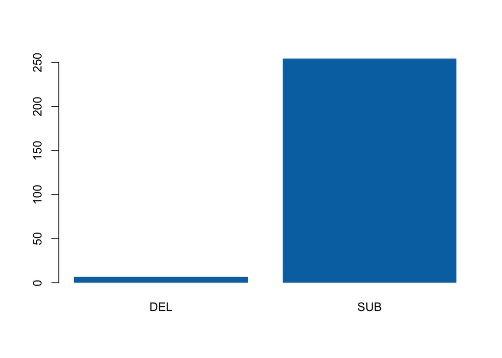

```r
r1 <- r_clean[r_clean$dist==1 & r_clean$id %in% GOOD_IDS,]
op1 <- sapply(r1$alg, function(l) l[!is.na(l)])
h <- tapply(op1, op1, length)
barplot(h, names.arg=c('DEL', 'SUB'), col=COL_DARKBLUE, border=NA)
```

```r
h
```

```
##  -1   0
##   7 254
```

We see that, under this metric, nearly all edits (254 of 261) are substitutions. Note that there are no insertions because of the way we compute chunk-based edit operations from token-based ones.

Hence, we focus on substitutions.

```r
r1_sub <- r1[op1==0,]
r1_sub$pos <- sapply(r1_sub$alg, function(l) which(!is.na(l)))
sub_pairs <- data.frame(t(apply(r1_sub, 1, function(row) {
  c(
    row$original_title_lumped,
    row$title_lumped,
    row$original_chunkLabels[row$pos],
    normalizeAndSplitString(row$original_title_lumped)[row$pos],
    normalizeAndSplitString(row$title_lumped)[row$pos],
    paste(row$ratings, collapse=','),
    mean(mean(row$ratings, na.rm=TRUE))
  )})))
colnames(sub_pairs) <- c('old_title', 'new_title', 'modified_chunk_label',
                         'old_chunk', 'new_chunk', 'ratings', 'mean_rating')
# Write the pairs with chunk-based edit distance 1 to file.
write.table(sub_pairs[order(sub_pairs$old_title),], sprintf("%s/pairs_editdist_1.tsv", DATADIR),
  sep='\t', row.names=FALSE, col.names=TRUE, quote=FALSE, fileEncoding="UTF-8")
```

From now on, we work with 254 pairs (labeled as serious by a majority; no-out-of-chunk tokens; no between-chunk insertions; exactly one chunk-based edit, which is a substitution).

If we sampled phrases to modify uniformaly at random (one per headline), what would be the histogram?

```r
phrase_types <- unique(unlist(r1_sub$original_chunkLabels))
prior_phrase_freqs <- sort(sapply(phrase_types,
                                  function(type) mean(apply(
                                    r1_sub, 1, function(x) mean(x$original_chunkLabels == type)))),
                           decreasing=TRUE)
```

Which phrases are modified most often?

```r
modified_phrase_freqs <- (tapply(sub_pairs$modified_chunk_label,
                                 sub_pairs$modified_chunk_label, length) /
                            nrow(sub_pairs))[names(prior_phrase_freqs)]
modified_phrase_freqs[is.na(modified_phrase_freqs)] <- 0
phrase_freqs <- data.frame(empirical=modified_phrase_freqs, prior=prior_phrase_freqs,
                           lift=modified_phrase_freqs/prior_phrase_freqs)
phrase_freqs
```

```
##        empirical       prior       lift
## NP   0.893700787 0.586279840 1.52435872
## VP   0.094488189 0.201520122 0.46887719
## PP   0.003937008 0.173957943 0.02263195
## ADVP 0.000000000 0.015184039 0.00000000
## ADJP 0.007874016 0.014899700 0.52846807
## PRT  0.000000000 0.006933508 0.00000000
## SBAR 0.000000000 0.001224847 0.00000000
```

Where in the headline to substitutions take place? We consider the sequence of edit operations needed to transform the original into the unfunned headline, and compute the position of the substitution in this sequence.

```
## [1] "Length 3 (N=24)"
```

```
## [1] "Length 4 (N=38)"
```

```
## [1] "Length 5 (N=123)"
```

```
## [1] "Length 6 (N=38)"
```

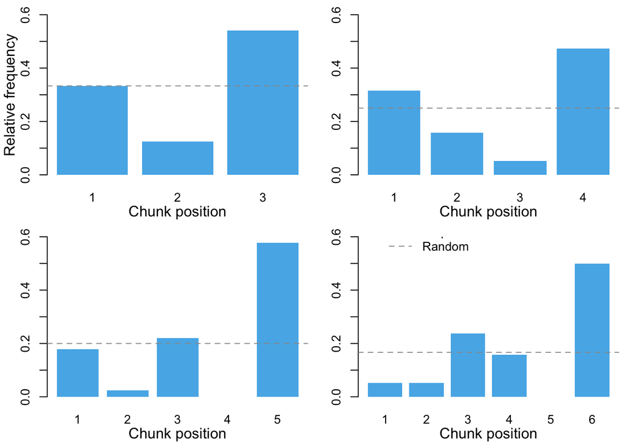

```r
draw_edit_pos_hist <- function(r_part, len, filename=NULL, width=NULL, print_ylab=TRUE, print_legend=FALSE) {
  h <- tapply(r_part$pos, r_part$pos, length)/length(r_part$pos)
  hh <- rep(0,len)
  names(hh) <- 1:len
  hh[names(h)] <- h
  if (SAVE_PLOTS && !is.null(filename))
    pdf(sprintf('%s/%s.pdf', PLOTDIR, filename), width=width, height=1.4, pointsize=9,
        family='Helvetica', useDingbats=FALSE)
  par(mar=c(3.2, 3.2, 1, 0.2))
  print(sprintf('Length %d (N=%d)', len, nrow(r_part)))
  barplot(hh, xlab='Position of substitution', ylab='', ylim=c(0,0.6), col=COL_LIGHTBLUE,
          border=NA)
  mtext('Chunk position', side=1, line=2)
  if (print_ylab) {
    mtext('Relative frequency', side=2, line=2)
  }
  abline(h=1/len, col=COL_GRAY, lwd=1, lty=2)
  if (print_legend) {
    legend(x=0.5, y=0.675, legend=c('Empirical', 'Random'), bty='n', lty=c(1,2), lwd=c(6,1),
           col=c(COL_LIGHTBLUE, COL_GRAY))
  }
  if (SAVE_PLOTS && !is.null(filename)) dev.off()
}

# For each length separately.
if (!SAVE_PLOTS) par(mfrow=c(2,2))
for (len in 3:6) {
  r1_sub_part <- r1_sub[apply(r1_sub, 1, function(x) length(x$alg)) == len,]
  draw_edit_pos_hist(r1_sub_part, len, sprintf('edit_pos_distrib_length=%d', len),
                     width=2.2*(0.82*len/6 + 0.18), print_ylab=(len==3), print_legend=(len==6))
}
```

```r
par(mfrow=c(1,1))
```

```r
chunk_patterns <- sapply(r$original_chunkLabels, function(x) paste(x, sep=" ", collapse=" "))

# Top chunk patterns among all pairs (i.e., not only successful ones with exactly one chunk-based substitution).
chunk_pattern_freq <- sort(tapply(chunk_patterns, chunk_patterns, length), decreasing=TRUE)
cbind(chunk_pattern_freq, chunk_pattern_freq / sum(chunk_pattern_freq))[1:10,]
```

```
##                     chunk_pattern_freq
## NP VP NP PP NP                     623 0.22242056
## NA                                 517 0.18457694
## NP VP NP                            91 0.03248840
## NP VP PP NP                         80 0.02856123
## NP PP NP                            76 0.02713317
## NP ADVP VP NP PP NP                 53 0.01892181
## NP VP NP VP NP                      44 0.01570868
## NP VP PP NP PP NP                   41 0.01463763
## NP NP PP NP                         34 0.01213852
## NP VP NP VP PP NP                   31 0.01106748
```

```
## [1] "Length 5 (N=100)"
```

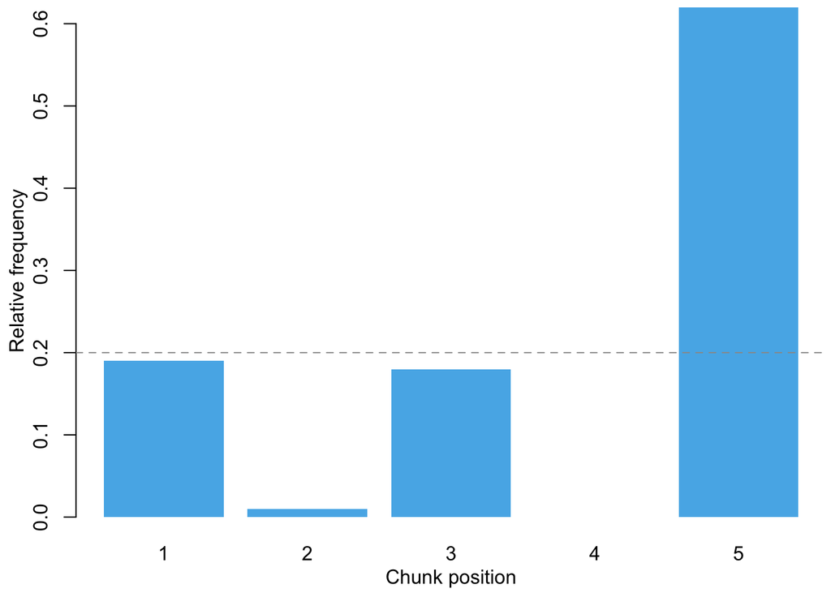

```r
# Pairs with the most frequent pattern (NP VP NP PP NP) with exactly one subsitution.
mask <- sapply(r1_sub$original_chunkLabels, function(x) paste(x, sep=" ", collapse=" ")) == 'NP VP NP PP NP'

# Separately for the most frequent chunk pattern (NP VP NP PP NP). Since positions 1, 3, 5 are all NP,
# this shows that the last position is modified not simply because it's an NP.
r1_sub_common_pattern <- r1_sub[mask,]
draw_edit_pos_hist(r1_sub_common_pattern, 5)
```

```r
# Plot average chunk length as a function of position.
chunk_lengths <- t(sapply(r1_sub_common_pattern$original_title_lumped,
                          function(t) sapply(splitAt(t, ' '), function(ch) length(splitAt(ch, '_')))))
colnames(chunk_lengths) <- 1:5
mean_and_ci <- as.data.frame(t(simplify2array(apply(chunk_lengths, 2, bootstrap_ci))))
```

```
## [1] "All values of t are equal to  1 \n Cannot calculate confidence intervals"
```

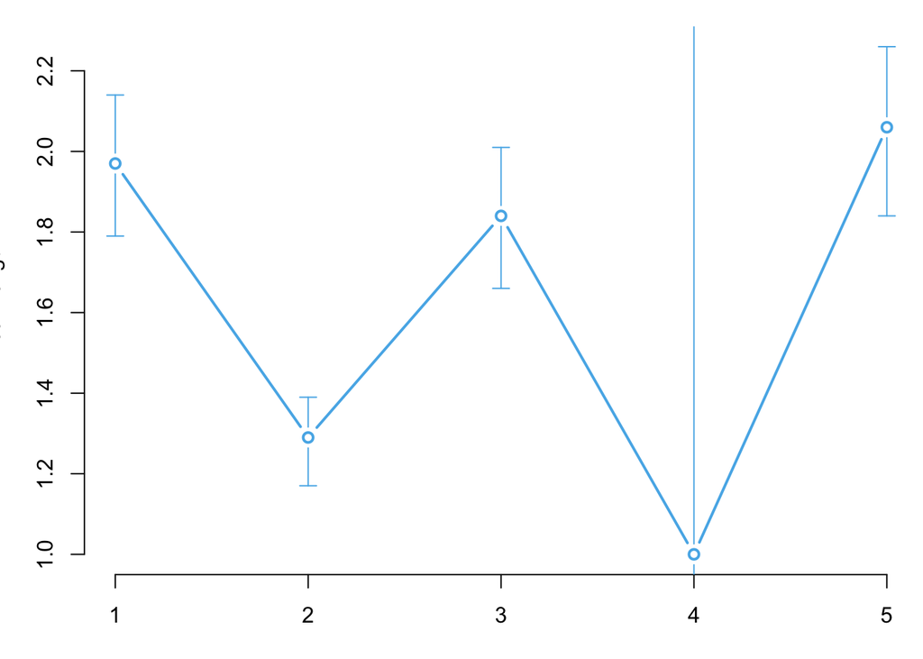

```r
x <- 1:5
y <- as.numeric(mean_and_ci$mean[x])
lo <- as.numeric(mean_and_ci$lower[x])
hi <- as.numeric(mean_and_ci$upper[x])
plot(x, y, ylim=range(c(lo, hi, y), na.rm=TRUE), type='b', bty='n', lwd=2, xlab='Chunk position', ylab='Mean length',
     col=COL_LIGHTBLUE)
dispersion(x, y, hi, lo, intervals=FALSE, col=COL_LIGHTBLUE)
```

```
## [1] "Length 5 (N=11)"
```

```
## [1] "Length 6 (N=39)"
```

```
## [1] "Length 7 (N=21)"
```

```
## [1] "Length 8 (N=20)"
```

```
## [1] "Length 9 (N=25)"
```

```
## [1] "Length 10 (N=14)"
```

```
## [1] "Length 11 (N=13)"
```

```
## [1] "Length 12 (N=6)"
```

```
## [1] "Length 13 (N=3)"
```

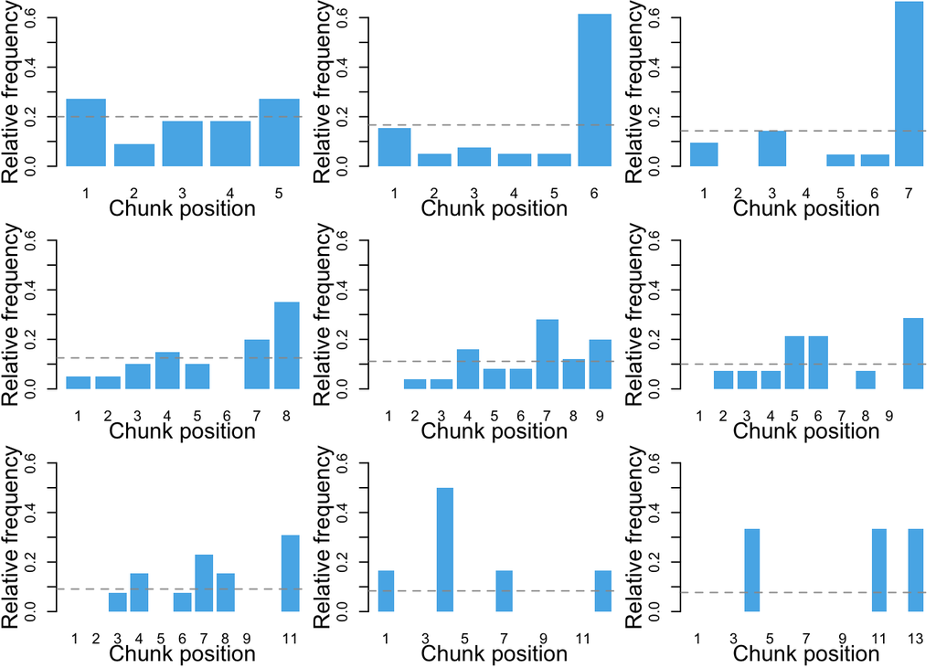

```r
# As a sanity check, repeat for token level, i.e., headlines with exactly one token-level substitution.
rrr <- r[r$id %in% GOOD_IDS & r$dist_plain == 1 & sapply(r$alg_plain, function(x) sum(x==0, na.rm=TRUE) == 1),]
rrr$pos <- sapply(rrr$alg_plain, function(l) which(!is.na(l)))
par(mfrow=c(3,3))
for (l in 5:13) {
  r_part <- rrr[rrr$origlen == l,]
  draw_edit_pos_hist(r_part, l)
}
```

```r
par(mfrow=c(1,1))
```

### Semantic analysis: script opposition

```r
for (c in c(8:14, 17:18)) {
  scr_opp[,c] <- as.logical(scr_opp[,c])
  scr_opp[is.na(scr_opp[,c]), c] <- FALSE
}

scr_opp <- scr_opp[!scr_opp$unfunning_failed & !scr_opp$not_clear_why_headline_funny, -(17:18)]

for (c in c('high.low.stature', 'non.obscene.obscene')) {
  memberships <- strsplit(scr_opp[,c], ', ')
  opps <- unique(unlist(memberships))
  for (o in opps) {
    scr_opp[, sprintf('%s_%s', c, make.names(o))] <- sapply(memberships, function(l) o %in% l)
  }
  scr_opp[,c] <- sapply(memberships, function(l) length(l) > 0)
}

means <- c(
colMeans(scr_opp[,8:10]),
colMeans(scr_opp[,c(11:14,16)]),
colMeans(scr_opp[,c(15,17:26)])
)

fracs <- data.frame(Class=names(means), Percentage=means, stringsAsFactors=FALSE)
rownames(fracs) <- 1:nrow(fracs)
fracs$Percentage <- sapply(fracs$Percentage, function(x) sprintf('%.0f\\%%', round(x*1000)/10))
fracs$Class <- sapply(fracs$Class, function(s) gsub('.*_(.*)', '\\1', s, perl=TRUE))

nice_names <- c(
"actual/non-actual",
"normal/abnormal",
"possible/impossible",
"life/death",
"no violence/violence",
"good/bad intentions",
"reasonable/absurd response",
"non-obscene/obscene",
"high/low stature",
"\\hspace{3mm} authority/no authority",
"\\hspace{3mm} solemn/mundane",
"\\hspace{3mm} human/object",
"\\hspace{3mm} sophisticated/simple",
"\\hspace{3mm} success/failure",
"\\hspace{3mm} rich/poor",
"\\hspace{3mm} modern/outdated",
"\\hspace{3mm} human/animal",
"\\hspace{3mm} religion/no religion",
"\\hspace{3mm} animal/object"
)
names(nice_names) <- fracs$Class
fracs$Class <- nice_names[fracs$Class]

print(xtable(fracs), hline.after=c(-1,0,3,nrow(fracs)), include.rownames=FALSE,
      sanitize.text.function=function(s) s)
```

```
## % latex table generated in R 3.4.0 by xtable 1.8-2 package
## % Thu Jan 10 15:19:40 2019
## \begin{table}[ht]
## \centering
## \begin{tabular}{ll}
##   \hline
## Class & Percentage \\
##   \hline
## actual/non-actual & 8\% \\
##   normal/abnormal & 28\% \\
##   possible/impossible & 64\% \\
##    \hline
## life/death & 9\% \\
##   no violence/violence & 10\% \\
##   good/bad intentions & 25\% \\
##   reasonable/absurd response & 17\% \\
##   non-obscene/obscene & 7\% \\
##   high/low stature & 68\% \\
##   \hspace{3mm} authority/no authority & 13\% \\
##   \hspace{3mm} solemn/mundane & 15\% \\
##   \hspace{3mm} human/object & 6\% \\
##   \hspace{3mm} sophisticated/simple & 10\% \\
##   \hspace{3mm} success/failure & 14\% \\
##   \hspace{3mm} rich/poor & 4\% \\
##   \hspace{3mm} modern/outdated & 5\% \\
##   \hspace{3mm} human/animal & 5\% \\
##   \hspace{3mm} religion/no religion & 3\% \\
##   \hspace{3mm} animal/object & 1\% \\
##    \hline
## \end{tabular}
## \end{table}
```

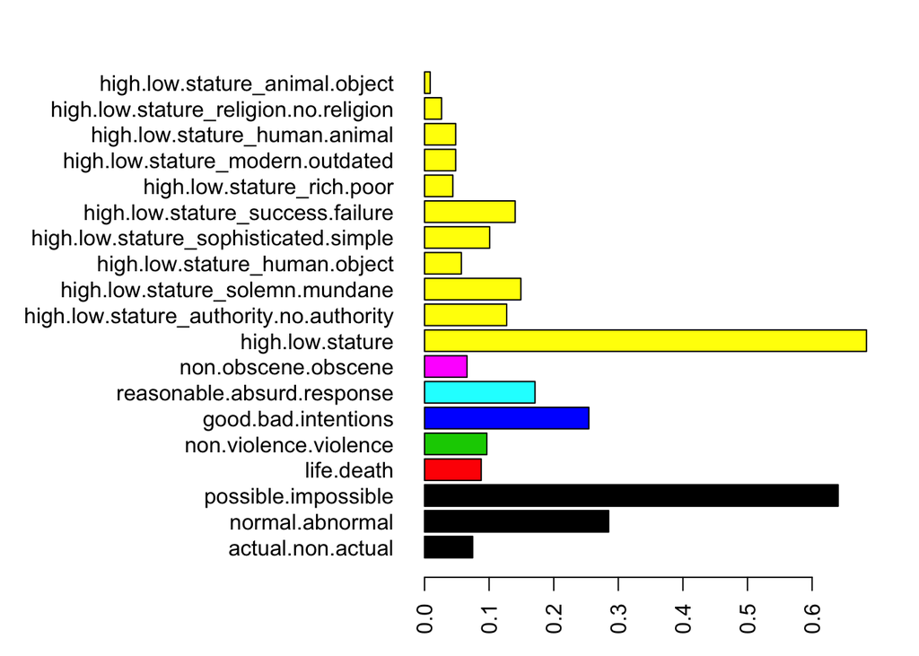

```r
par(mar=c(3,16,2,2))
barplot(means, horiz=TRUE, las=2, col=c(1,1,1, 2:6, rep(7, 11)))
```